# Лабораторная работа №7

Операционные системы

Дьяконова Софья Александровна

Российский университет дружбы народов, Москва, Россия

15 марта 2023

## Докладчик

- Дьяконова Софья Александровна
- студентка из группы НКАбд-01-22
- Факультет физико-математических и естественных наук
- Российский университет дружбы народов
- 1132220829@rudn.ru
- https://github.com/sadjyakonova/study_2022-2023_os-intro/tree/master/labs

## Цель работы

Цель данной лабораторной работы - освоение основных возможностей командной оболочки Midnight Commander, приобретение навыков практической работы по просмотру каталогов и файлов; манипуляций с ними

## Выполнение лабораторной работы

## С помощью команды man mc прочитала документацию про командную оболочку.

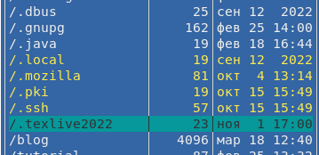

Запускаю из командной строки mc, изучаю его структуру и меню.

## Выполняю несколько операций в mc,

используя управляющие клавиши (операции с панелями; выделение/отмена выделения файлов, копирование/перемещение фай- лов, получение информации о размере и правах доступа на файлы и/или каталоги и т.п.)

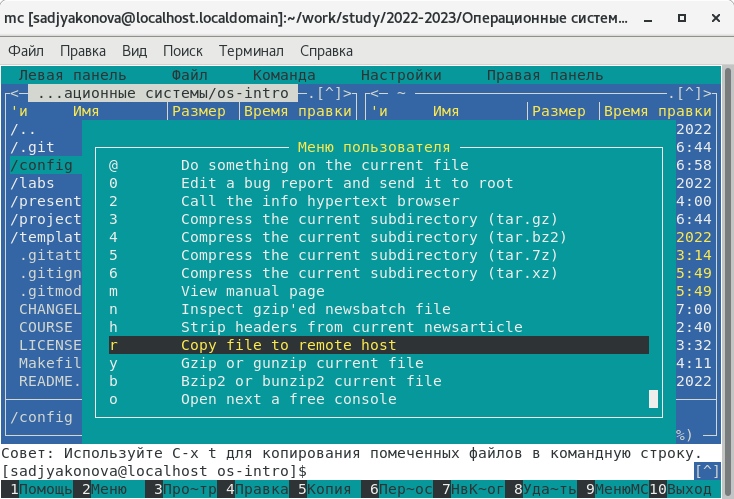

## Используя возможности подменю Файл , выполняю:

[figure not shown]

[figure not shown]

## Вызываю подменю Настройки . Освойте операции, определяющие структуру экрана mc (Full screen, Double Width, Show Hidden Files и т.д.)

## Создаю текстовый файл text.txt.

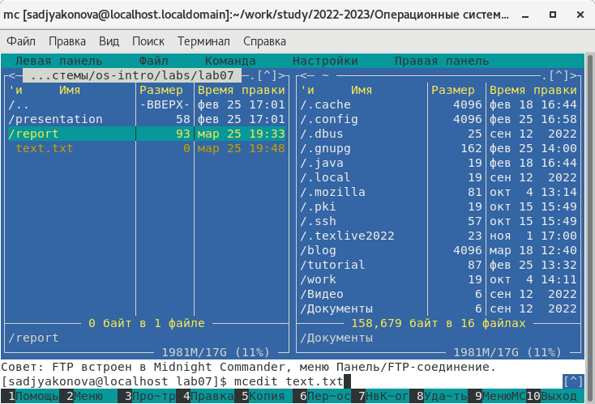

Создание файла

## Открываю этот файл с помощью встроенного в mc редактора.

У меня не получилось вставить текст из интернета, думаю проблема в переназаначении горячих клавиш.

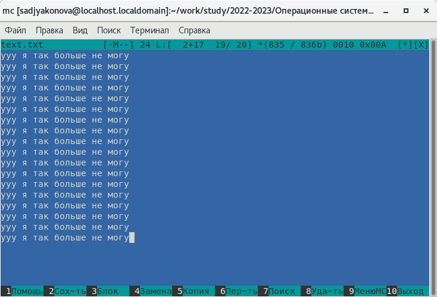

## Выводы

При выполнениии данной лабораторной работы я освоила основные возможности командной оболочки Midnight Commander, приобрела навыки практической работы по просмотру каталогов и файлов; манипуляций с ними